# dolin_agnes_plankton

### Plankton Challenge by Felix DOLIN and Vincent AGNES

In this Notebook you'll find, **in every blue cell , our comments and answers** .

We've started by exploring the datasets: images and csv files(meta, taxo, features_native, features_skimage).  
As we've already struggled with dataframe cleaning and exploiting in the first challenge, we decided to focus first on the images.  
Our first goal has been to explore these images and we've discovered the relation between the **image files** and the file **meta** . We've read some articles about CNN and different way to deal with image recognition.

##### In this Notebook we've tried to summarize every **difficulties and problems** we've faced and how we managed to solve them.

```python
import numpy as np
import pandas as pd
import zipfile
import scipy
import keras
from sklearn.model_selection import train_test_split, StratifiedKFold
import matplotlib.pyplot as plt
from io import BytesIO
from PIL import Image
from sklearn.metrics import f1_score
from sklearn.preprocessing import LabelEncoder
from skimage.transform import resize
```

```python
meta = pd.read_csv("/mnt/datasets/plankton/flowcam/meta.csv")
meta.dropna(axis = 'index', inplace = True)
```

```python
LIGHT_FILE_SIZE = 100000 #The size of the light file used to train our model in order to save time (See the next parts to know more about it)

def extract_zip_to_memory(input_zip):
    '''
    This function extracts the images stored inside the given zip file.
    It stores the result in a python dictionary.

    input_zip (string): path to the zip file

    returns (dict): {filename (string): image_file (bytes)}
    '''
    input_zip=zipfile.ZipFile(input_zip)
    return {name: BytesIO(input_zip.read(name)) for name in input_zip.namelist() if name.endswith('.jpg')}


img_files = extract_zip_to_memory("/mnt/datasets/plankton/flowcam/imgs.zip")
img_files_light = {}
meta_light = meta.head(LIGHT_FILE_SIZE)

for objid in meta_light.index:
    path = 'imgs/'+ str(int(objid)) + '.jpg'
    img_files_light[path] = img_files[path]
```

### 1. Data Exploration

Here are our first exploration, You'll find some more intersting data investigation in the following: We've often tried to gather the data discovery (which often lead to a problem that we have to solve) with the solution that we've implemented.

```python
print("shape of meta :", meta.shape)
```

```
shape of meta : (239989, 14)
```

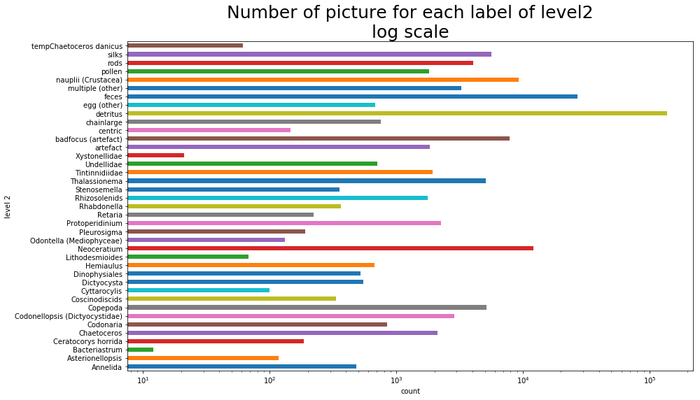

```python
df=meta.copy()
df.drop(['projid','id','status','latitude','longitude','objdate','objtime','depth_min','depth_max','lineage','level1'],axis = 1, inplace = True)
df=df.groupby('level2').size()
fig,ax=plt.subplots(figsize=(14,8))

df.plot(kind='barh',ax=ax)

ax.set_ylabel('level 2')
ax.set_xlabel('count')

title=plt.title('Number of picture for each label of level2'+'\n'+'log scale')
title.set_fontsize(25)

plt.tight_layout()
ax.set_xscale("log")
plt.show()
```

We can see the label 'detritus' is the most represented one. Then, 'bad focus' and 'artefact' are also very numerous. We've first thought about removing these pictures but our algorithm has to be able to recognize a detritus. Still, it is going to be hard as some label present only a few pictures (the log scale is to blame here).

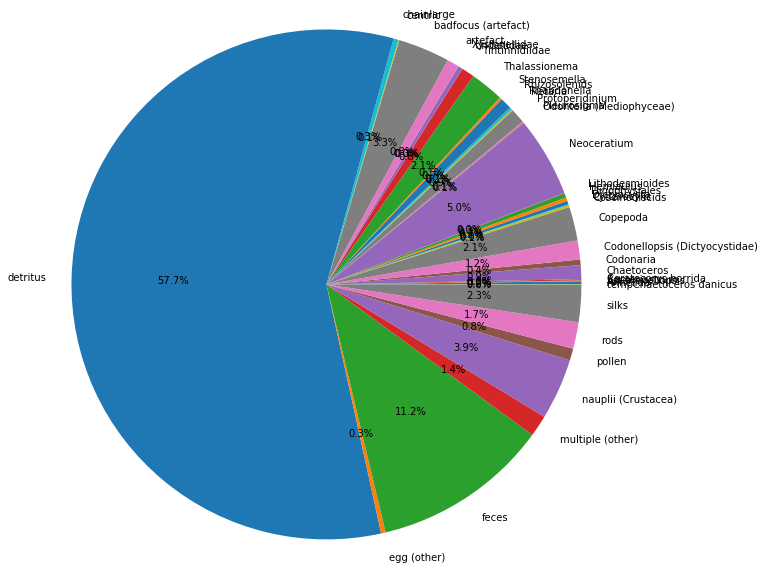

```python
labels =df.index
sizes = list(df)
plt.figure(figsize=(8,8))
plt.pie(sizes, labels=labels, autopct='%1.1f%%',  startangle=0)
plt.axis('equal')
plt.tight_layout()
plt.show()

del df
```

Here we can better see that some class are way less represented than other and especially we can see that more than one picture out of two is a detritus.

We decided to work with **Neural Networks** in order to get some experiment on them because it's something that appeal to us. Furthermore, the features extraction seemed to be heavy, not very rewarding and not very different from the HousePricing Challenge. Hence, the aim of the pre-processing is to build 'train_X' and 'train_Y' : the data that will be given to our neural network

### 2.1 Data Pre-processing

```python
meta.set_index('objid', inplace = True) # to be able to delete an input of our dataset, even if we only know objid (and not the previoux index)
print(meta.index[:5])
meta.drop(['projid','id','status','latitude','longitude','objdate','objtime','depth_min','depth_max','lineage','level1'],axis = 1, inplace = True)

meta = meta.sample(frac=1) # shuffle to ensure that the different categories will be randomly distributed in the dataframe
print(meta.index[:5])
```

```python
NB_DETRITUS_DROPPED = int(0.2*len(meta))

##compute the mean shape of images in our dataset and remove non-relevant images
cleaned_meta = meta.copy()
height = []
width = []
counter = 0
for objid in meta.index:
    path = 'imgs/'+ str(int(objid)) + '.jpg'
    np_im = np.array(Image.open(img_files[path]))
    n,m = np_im.shape
    if n<15 or m<15: #with less than 15 pixel we consider that the data is not relevant
        cleaned_meta.drop(objid,'index', inplace = True)
        del img_files[path]
        counter+=1
    height.append(n)
    width.append(m)

detritus_dropped = cleaned_meta[cleaned_meta['level2']=='detritus'].sample(frac=1).head(NB_DETRITUS_DROPPED)
cleaned_meta.drop(detritus_dropped.index, 'index', inplace = True)

del meta
```

NB : if an image had another number of channel than 1, the line ``` n,m = np_im.shape``` wouldn't compile

```python
print('average height          : ', sum(height) / len(height))
print('average width           : ', sum(width) / len(width))
print('min/max height          : ', min(height),' / ', max(height))
print('min/max width           : ', min(width),' / ', max(width))
print('mean ratio height/width : ', sum([height[i]/width[i] for i in range(len(height))])/len(height))
print('5% height percentile    : ', np.percentile(height,5) )
print('5% width  percentile    : ', np.percentile(width,5) )
print('we deleted ',counter,' images because of their shape')
```

```
average height          :  108.70173632958178
average width           :  86.24010267137244
min/max height          :  2  /  739
min/max width           :  2  /  972
mean ratio height/width :  1.6547141704104904
5% height percentile    :  43.0
5% width  percentile    :  29.0
we deleted  1558  images because of their shape
```

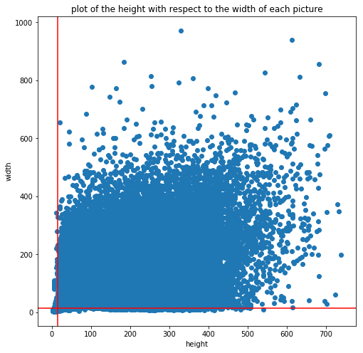

```python
plt.figure(figsize=(8,8))
plt.plot(height,width,'o')
plt.title('plot of the height with respect to the width of each picture')
plt.xlabel('height')
plt.ylabel('width')
plt.axvline(x=15,color='red')
plt.axhline(y=15,color='red')
plt.show()
```

```python
def compterTri(tab):
    LX=[]
    LY=[]
    trie = sorted(tab)
    compteur = 1
    avant = None
    compteur2=0
    for v in trie:
        compteur2+=1
        if v == avant:
            compteur += 1
        elif avant != None:
            LX.append(avant)
            LY.append(compteur)
            compteur = 1
        if compteur2==len(trie) :
            LX.append(avant)
            LY.append(compteur)
        avant = v
    return LX,LY,compteur2
```

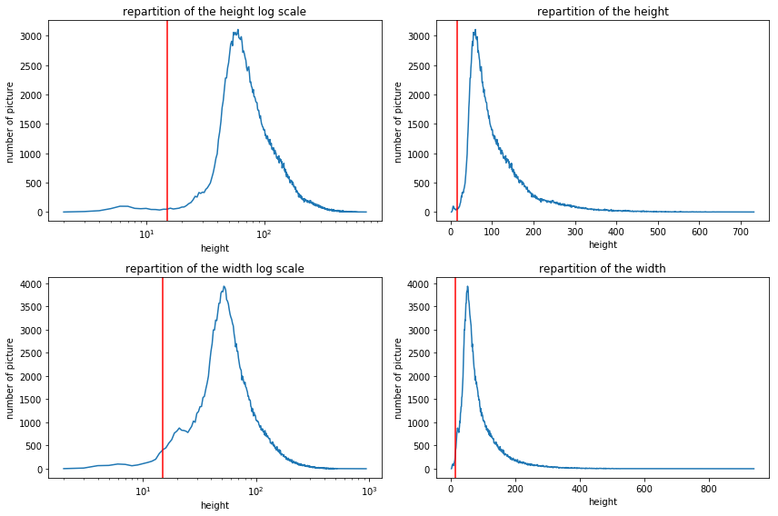

```python
LX,LY,c=compterTri(height)
plt.figure(figsize=(12,8))

plt.subplot(2,2,1)
plt.title('repartition of the height log scale')
plt.semilogx()
plt.xlabel('height')
plt.ylabel('number of picture')

plt.plot(LX,LY)
plt.axvline(x=15,color='red')


plt.subplot(2,2,2)
plt.title('repartition of the height')
plt.plot(LX,LY)
plt.axvline(x=15,color='red')
plt.xlabel('height')
plt.ylabel('number of picture')


LX,LY,c=compterTri(width)
plt.subplot(2,2,3)
plt.title('repartition of the width log scale')
plt.semilogx()
plt.plot(LX,LY)
plt.axvline(x=15,color='red')
plt.xlabel('height')
plt.ylabel('number of picture')


plt.subplot(2,2,4)
plt.title('repartition of the width')
plt.plot(LX,LY)
plt.axvline(x=15,color='red')
plt.xlabel('height')
plt.ylabel('number of picture')


plt.tight_layout()

plt.show()
```

These graphs represent the number of pictures with respect to the height and the width. It shows that most of the picture have a size in the range (20,200). The red line represents the limit between picture we've decided to keep and pictures we've decided to ignore because they were too small and not really usable.

```python
def to_numpy(img_files, df, img_shape):
    """img_files is a dictionary which refers to images whose index is described in the dataframe df
    :param img_shape: is the shape of the images ((28,28) for instance)
    NOTE : I assumed that every image referenced in the dataframe was indeed in the dictionary
    """
    nb_inputs,_ = df.shape
    final_array = np.zeros((nb_inputs,img_shape[0],img_shape[1]))

    for i,objid in enumerate(df.index):
        path = 'imgs/'+ str(int(objid)) + '.jpg'
        img = Image.open(img_files[path])
        img_resized = img.resize((img_shape[0],img_shape[1]), Image.ANTIALIAS)
        np_im = np.array(img_resized)
        np_im = np.reshape(np_im, img_shape)
        final_array[i,:,:] = np_im
    return final_array

def zmuv(array_img):
    """zero mean unit variance
    DO NOT USE IT : THE MEAN IS NOT COMPUTED ALONG THE RIGHT AXIS
    :param array_img: should be a  numpy array of dimension NxSxS where N is the size of our dataset and SxS the size of our pictures"""

    means = array_img.mean(axis = 0) #vector of the means
    stds = array_img.std(axis = 0)

    zmuv_img = (array_img - means)/stds

    return zmuv_img

def train_test(X, Y, test_size = 0.2):
    """:return: the X and Y data, for training and testing
                reminder : testing data should not be used for validation in the model"""

    n,_,_ = X.shape
    n_test = int(test_size*n)
    index_X = np.arange(n)
    index_test = np.random.choice(index_X, n_test, replace=False)
    test_X = X[index_test,:,:]
    test_Y = Y[index_test]
    train_X = X[index_X,:,:]
    train_Y = Y[index_X]

    return train_X, train_Y, test_X, test_Y

def prepare_for_training(X, cleaned_df, test_size=0.1, img_size=32) :
    '''
    :param X: the images NOT centered/normalized !
    :param cleaned_df: the dataframe which contains the information to generate our 'Y' (should be a sub-dataframe from meta)
    '''

    nb_categories= len(cleaned_df['level2'].unique())
    le = LabelEncoder()
    Y_num = le.fit_transform(np.array(cleaned_df['level2'])) # transforms the string into numerical categories

    train_X, train_Y, test_X, test_Y = train_test(X, Y_num, test_size = test_size)

    train_X = zmuv(train_X).reshape(-1,img_size,img_size,1)
    test_X = zmuv(test_X).reshape(-1,img_size,img_size,1)

    return train_X, test_X, train_Y, test_Y, nb_categories
```

To improve our predictions, we've decided to increase the size of our dataset for classes that are not represented too much. To do so, we wanted to keep the same structure so we modifie the meta dataframe and also the array containing every pictures(in which we qdd the flipped/rotated/zoomed one.

```python
def to_numpy_generator (img_files, df, img_shape):
    '''This function should do the same work as the to_numpy function.
    It also looks for the less represented class and increase the number of images for these classes by flipping, rotating ... '''
    nb_inputs,_ = df.shape
    final_array = np.zeros((nb_inputs,img_shape[0],img_shape[1]))

    ### Here we look for the 'little classes'
    class_too_small=[]
    liste = df.groupby('level2').size()
    counter=0
    for i in liste.index :
        if liste[i] <= 0.025*nb_inputs:
            counter=counter+liste[i]
            class_too_small.append(i)
    ###

    additional_array=np.zeros((counter*4,img_shape[0],img_shape[1]))
    counter2=0
    for i,objid in enumerate(df.index):
        path = 'imgs/'+ str(int(objid)) + '.jpg'
        img = Image.open(img_files[path])
        img_resized = img.resize((img_shape[0],img_shape[1]), Image.ANTIALIAS)
        np_im = np.array(img_resized)

        np_im = np.reshape(np_im, img_shape)
        final_array[i,:,:] = np_im
        category = df.loc[objid].level2
        if category in class_too_small: ### Here we add images when the class is 'little'
            df,additional_array=img_generator(additional_array, np_im, counter2,df,category,img_shape)
            counter2+=4

    final_array2 = np.concatenate((final_array,additional_array) )  #careful : we'll have to reshuffle the array
    return final_array2,df

def img_generator(additional_array, np_im, counter2,df,category,img_shape):
    '''This function is called in the to numpy genertor function'''
    i1=np.flipud(np_im)
    i2=np.fliplr(np_im)
    i3 = np.zeros(np_im.shape)
    i3=scipy.ndimage.rotate(np_im,np.random.randint(0,180),mode='constant', cval=255, axes=(1, 0))
    i3 = resize(i3, img_shape, anti_aliasing=True, mode = 'reflect')
    i4=scipy.ndimage.rotate(np_im,np.random.randint(0,180), mode='constant', cval=255, axes=(1, 0) )
    i4 = resize(i4, img_shape, anti_aliasing=True, mode = 'reflect')
#     i5=scipy.ndimage.rotate(np_im,np.random.randint(0,180), mode='constant', cval=255, axes=(1, 0) )
#     i5 = resize(i5, img_shape, anti_aliasing=True, mode = 'reflect')
#     i6=scipy.ndimage.rotate(np_im,np.random.randint(0,180), mode='constant', cval=255, axes=(1, 0) )
#     i6 = resize(i6, img_shape, anti_aliasing=True, mode = 'reflect')
    additional_array[counter2,:,:]=i1
    additional_array[counter2+1,:,:]=i2
    additional_array[counter2+2,:,:]=i3
    additional_array[counter2+3,:,:]=i4
#     additional_array[counter2+4,:,:]=i5
#     additional_array[counter2+5,:,:]=i6
    df2=pd.DataFrame({'level2' : [category for i in range(4)]})
    df = pd.concat([df,df2], axis=0, join = 'inner', sort=False)
    return df,additional_array
```

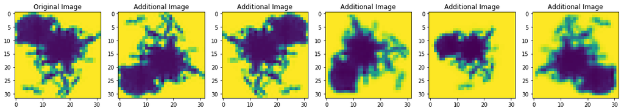

```python
plt.figure(figsize=(20,20))
plt.subplot(1,6,1)
plt.title('Original Image')
plt.imshow(np_im)
plt.subplot(1,6,2)
plt.title('Additional Image')
plt.imshow(np.flipud(np_im))
plt.subplot(1,6,3)
plt.title('Additional Image')
plt.imshow(np.fliplr(np_im))
plt.subplot(1,6,4)
plt.title('Additional Image')
rot=scipy.ndimage.rotate(np_im,np.random.randint(0,180), mode='constant', cval=255, axes=(1, 0) )
rot = resize(rot, (32,32), anti_aliasing=True, mode = 'reflect')
plt.imshow(rot)
plt.subplot(1,6,5)
plt.title('Additional Image')
rot=scipy.ndimage.rotate(np_im,np.random.randint(0,180), mode='constant', cval=255, axes=(1, 0) )
rot = resize(rot, (32,32), anti_aliasing=True, mode = 'reflect')
plt.imshow(rot)
plt.subplot(1,6,6)
plt.title('Additional Image')
rot=scipy.ndimage.rotate(np_im,np.random.randint(0,180), mode='constant', cval=255, axes=(1, 0) )
rot = resize(rot, (32,32), anti_aliasing=True, mode = 'reflect')
plt.imshow(rot)

plt.show()
```

Above you can see a set of random (because the angle of rotation is random) additional image that we add to our database for each image that is in a 'little class'. It permits to **multiply by 6** the size of the 'little class. Still ,in the following, because of memory problem we will only keep 4 of the additional picture and remove some of the detritus

```python
array_img32, augmented_meta = to_numpy_generator(img_files, cleaned_meta, (32, 32))
# array_img60 = to_numpy(img_files, cleaned_meta, (60, 60))
del img_files
```

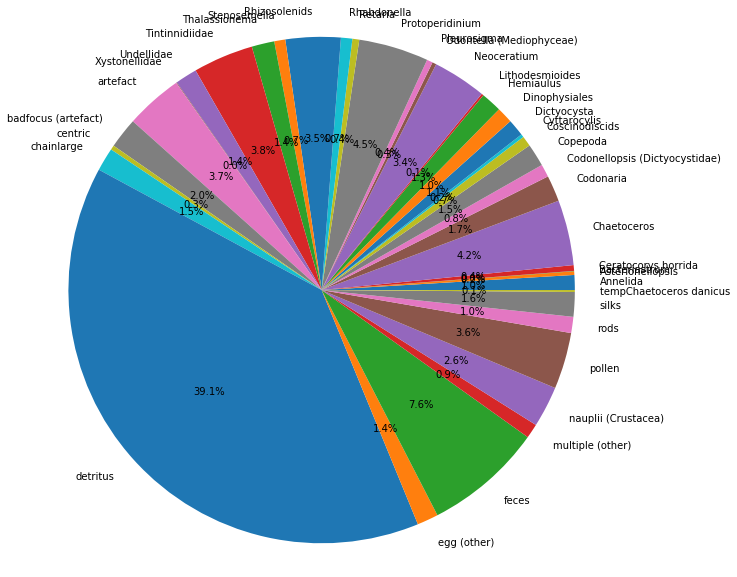

```python
df=augmented_meta
# df.drop(['projid','id','status','latitude','longitude','objdate','objtime','depth_min','depth_max','lineage','level1'],axis = 1, inplace = True)
df=df.groupby('level2').size()
labels =df.index
sizes = list(df)
plt.figure(figsize=(8,8))
plt.pie(sizes, labels=labels, autopct='%1.1f%%',  startangle=0)
plt.axis('equal')
plt.tight_layout()
plt.show()
```

We can see that the generation of datas was efficient. Indeed this graph was plotted in the first part and **now the repartition is preferable** (we could have balance more but it would have meant a to big amount of data. Doing this, we hope to increase our f1_score because at the beginning we weren't good at predicting some classes. In practice, the modification of the proportions of each class seems to disturb strongly our models. We faced two problems :

1. Due to memory problems, we haven't been able to load the whole dataset (which would have contained about 390 000 images). We've had to work with 150 000 images... Which is a shame, and might introduce a bias.
2. Even if we had solved our memory problems, we haven't had enough time to adapt our models to the 'augmented' dataset : the parameters weren't optimized and we did overfit most of the time.

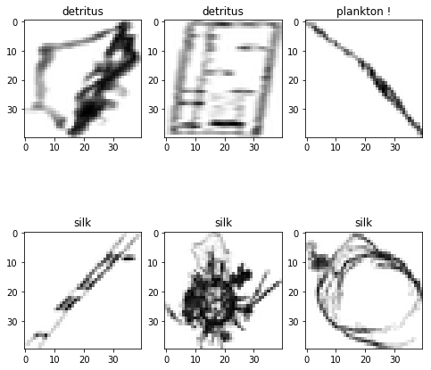

```python
fig=plt.figure(figsize=(8, 8))
columns = 3
rows = 2
for i in range(1, columns*rows +1):
    fig.add_subplot(rows, columns, i)
    if i<3:
        plt.title("detritus")
    elif i==3:
        plt.title("plankton !")
    else:
        plt.title("silk")
    plt.imshow(array_img40[i,:,:],cmap = 'gray')
plt.show()
```

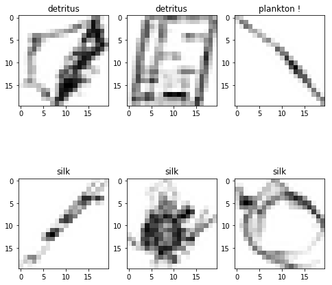

```python
fig=plt.figure(figsize=(8, 8))
columns = 3
rows = 2
for i in range(1, columns*rows +1):
    fig.add_subplot(rows, columns, i)
    if i<3:
        plt.title("detritus")
    elif i==3:
        plt.title("plankton !")
    else:
        plt.title("silk")
    plt.imshow(array_img20[i,:,:],cmap = 'gray')
plt.show()
```

We can see that with 20x20pixels, the images begin to be difficult to recognize... For our tests, we'll choose the 32x32 shape :

- to limit the amount of input data for our NeuralNetwork.
- to ensure that most of the images will be scaled down ([this article](https://medium.com/neuronio/how-to-deal-with-image-resizing-in-deep-learning-e5177fad7d89) tells us that it might be more performant than upscaling), since 95% are greater than 30 pixel wide or 43 pixel heigh.
- to ensure that the images are recognisable indeed.
- To be optimal when training Lenet-5 model (see in the dedicated section)

NOTE : in our experience, working with images of size 50x50 has proved to be harmless for our dataset... But 50 was still far below the mean shape (108x86)

```python
train_X32, test_X32, train_Y32, test_Y32, nb_categories = prepare_for_training(array_img32, augmented_meta, img_size=32)
del array_img32
```

[figure not shown]

Here is typically one of our most challenging problem: dealing with **memory** problem

The picture shows that we are reaching the memory limit of Zoe for our implementation. This challenge has forced us to get familiar with several of these tools to understand what went wrong and how to solve it. We've tried to use del to free some memory but it did not seem to work properly. We might have corrected it through 'forcing' the garbage collector to collect unreferenced objects in memory, but the right solution would more have been to use a Data loader... Yet, it was too late when we realised that, and we decided to work with a subset when the spatial cost was to important.

## 2.1 Light data treatment for development

This part was intended :

1. to avoid struggling with memeory problem while training several models. We can choose the size of the training set which we have often set to 150000 to be consistent and to rely on a big-enough dataset.
2. to be easier for us to develop our functions... It's better to test them with 200 images than 240 000 !

```python
cleaned_meta_light = meta_light.copy()
counter = 0
for objid in meta_light.index:
    path = 'imgs/'+ str(int(objid)) + '.jpg'

    np_im = np.array(Image.open(img_files_light[path]))
    n,m = np_im.shape
    if n<15 or m<15: #with less than 15 pixel we consider that the data is not relevant
        cleaned_meta_light.drop(objid,'index', inplace = True)
        del img_files_light[path]
        counter+=1

print("we deleted ",counter," images")
```

```
we deleted  653  images
```

```python
###EXECUTE THIS CELL IF YOU'RE HANDLING 32x32 IMAGES WITH DATA AUGMENTATION
array_img32_light, augmented_meta_light = to_numpy_generator(img_files_light, cleaned_meta_light, (32, 32))
del img_files_light
train_X32, test_X32, train_Y32, test_Y32, nb_categories = prepare_for_training(array_img32, cleaned_meta_light, img_size=32)
del cleaned_meta_light
```

```python
###EXECUTE THIS CELL IF YOU'RE HANDLING 50x50 IMAGES WITHOUT DATA AUGMENTATION
array_img50 = to_numpy(img_files_light, cleaned_meta_light, img_shape = (50,50))
del img_files_light
train_X50, test_X50, train_Y50, test_Y50, nb_categories = prepare_for_training(array_img50, cleaned_meta_light, img_size=50)
del cleaned_meta_light,array_img50
```

```python
###EXECUTE THIS CELL IF YOU'RE WORKING ON THE WHOLE DATASET, WITH 32x32 IMAGES
array_img32 = to_numpy(img_files, cleaned_meta, img_shape = (32,32))
del img_files
train_X32, test_X32, train_Y32, test_Y32, nb_categories = prepare_for_training(array_img32, cleaned_meta, img_size=32)
del cleaned_meta ,array_img32
```

### 3. Model Selection

First, we wanted to use TensorFlow since it's the one we'll study in DeepLearning, but it has been to complicated and we were loosing a lot of time. Thus, we turned to Keras because it is a high-level API : easier to handle and with a good documentation. Convolutional Neural Networks are known to be especially relevant for image recognition. Indeed, doing a convolution allows to extract directly the relations between neighbour pixels. Hence, we should focus on the first layers, but remaining careful to avoid overfitting. Considering the size of the dataset and the time limitation from Zoe, we chose to use the ```ReLu``` activation function because the computation is easier. We also used the ```adam``` optimizer because the optimisation of the learning rate is computationnaly costly and we prefered to use our time to find a good model. Finally, we used ```sparse_categorical_entropy``` in order to avoid building a binary matrix (which would have been costly in term of memory)

```python
from keras.models import Sequential
from keras.layers import Dense, Conv2D, Flatten, MaxPooling2D, AveragePooling2D, Dropout
```

We followed a precise approach :

1. A simple base as a model
   1. small images
   2. bigger images
   3. with data augmentation (but not the whole dataset because of some unidentified bad handling of our memory space)
   4. What if we complexify the network (width)?
   5. What if we complexify the network (depth)?
2. A proven model
   1. small images
   2. bigger images
   3. with data augmentation (but not the whole dataset because of some unidentified bad handling of our memory space)
   4. what about a proven and more complex model ?
3. What if we chose something else than a CNN ?
   - PCA + other models of supervised classification

note : we weren't able to implement data augmentation on bigger images because of the memory as well

## 1. Simple model

#### A. small images

*(no augmentation)*

```python
#create a simple model
model = Sequential()
#add model layers
model.add(Conv2D(60, kernel_size=3, activation='relu', input_shape=(32,32,1)))
model.add(MaxPooling2D(pool_size = (2,2)))
model.add(Conv2D(40, kernel_size=3, activation= 'relu'))
model.add(MaxPooling2D(pool_size = (2,2)))
model.add(Flatten())
model.add(Dense(nb_categories, activation='softmax'))

#compile model using accuracy to measure model performance
model.compile(optimizer='adam', loss='sparse_categorical_crossentropy', metrics=['accuracy'])

#train the model
model.fit(train_X32, train_Y32, validation_split = 0.2, epochs=8)
```

```
Train on 190744 samples, validate on 47687 samples
```

```
<keras.callbacks.History at 0x7f95cb376be0>
```

```python
y_pred=model.predict(test_X32)
y_pred=np.argmax(y_pred,axis=1)
score_32 = f1_score(test_Y32, y_pred, average=None)
print('test on ',len(test_Y32), ' samples')
print('f1 score : ',f1_score(test_Y32, y_pred, average='macro'))
```

```
test on  23843  samples
f1 score :  0.5260672088647821
```

```python
print('to have an idea of the distribution of the performances depending on the class :\n',score_32)
```

```
to have an idea of the distribution of the performances depending on the class :
 [0.45652174 0.23529412 0.37037037 0.42813456 0.41322314 0.74779541
 0.49255751 0.71052632 0.4        0.53164557 0.22222222 0.55769231
 0.4        0.84079372 0.82926829 0.47619048 0.70720721 0.30769231
 0.50746269 0.45255474 0.         0.80513919 0.61829653 0.7388535
 0.66666667 0.48965517 0.86346863 0.16666667 0.3960396  0.85194359
 0.65486726 0.5352173  0.15466667 0.68864469 0.59162304 0.58273381
 0.59891892 0.5       ]
```

CONDITIONS  
Whole dataset RESULTS  
The model behaves "quite good" (compared to others) on many classes but still 'forgets' some of them (5 below 25%, 1 not predicted), which draws our score lower. No overfitting But these predictions are obviously useless for _le musée océanographique_... As well as the following

NOTE : Looking at the previous cells, we may think that our neural network is not learning 'general' featurs anymore after the 3rd epoch but specific ones. Yet, when we pushed the number of epoch, we realised that f1-score was still increasing (and thus that our NN was still improving on some categories)... It was not obvious with the accuracy because of the weight of the detritus and feces, which determine most of the accuracy (they represent more than 2/3 of the data !)

#### 1.B bigger images

*(no augmentation)*

```python
#create a simple model
model50 = Sequential()
#add model layers
model50.add(Conv2D(60, kernel_size=3, activation='relu', input_shape=(50,50,1)))
model50.add(MaxPooling2D(pool_size = (2,2)))
model50.add(Conv2D(40, kernel_size=3, activation= 'relu'))
model50.add(MaxPooling2D(pool_size = (2,2)))
model50.add(Flatten())
model50.add(Dense(nb_categories, activation='softmax'))

#compile model using accuracy to measure model performance
model50.compile(optimizer='adam', loss='sparse_categorical_crossentropy', metrics=['accuracy'])

#train the model
model50.fit(train_X50, train_Y50, validation_split = 0.2, epochs=8)
```

```
Train on 119208 samples, validate on 29802 samples
```

```
<keras.callbacks.History at 0x7fb36817d710>
```

```python
y_pred=model50.predict(test_X50)
y_pred=np.argmax(y_pred,axis=1)
score = f1_score(test_Y50, y_pred, average = None)
print('test on ',len(test_Y50), ' samples')
print('f1 score : ',f1_score(test_Y50, y_pred, average='macro'))
```

```
test on  14901  samples
f1 score :  0.8019516543354354
```

```python
score
```

```
array([0.8       , 0.82352941, 0.92857143, 0.86446886, 0.69565217,
       0.85959885, 0.66961652, 0.85714286, 0.75      , 0.83018868,
       0.66666667, 0.77777778, 0.93333333, 0.88807339, 0.8       ,
       0.86956522, 0.80254777, 0.85714286, 0.89285714, 0.75925926,
       0.5       , 0.86871961, 0.85446009, 0.88659794, 1.        ,
       0.70848708, 0.94603904, 0.8       , 0.81690141, 0.88564109,
       0.78481013, 0.6260922 , 0.50777202, 0.7827529 , 0.76635514,
       0.73504274, 0.78961039, 0.88888889])
```

CONDITIONS  
Reduced dataset (150k images, no augmentation)  
Image size : 50 RESULTS  
Our best results. We overfit slightly but still the model is not so bad on every classe, and does not forget any ! To be really sure that this is a good model, we should verify that plankton-classes are not among the "low ranked" classes, but we laked of time.

#### 1.C Data augmentation

```python
#create a simple model
model = Sequential()
#add model layers

model.add(Conv2D(60, kernel_size=3, activation='relu', input_shape=(32,32,1)))
model.add(MaxPooling2D(pool_size = (2,2)))
model.add(Conv2D(40, kernel_size=3, activation= 'relu'))
model.add(MaxPooling2D(pool_size = (2,2)))
model.add(Flatten())
model.add(Dense(nb_categories, activation='softmax'))

#compile model using accuracy to measure model performance
model.compile(optimizer='adam', loss='sparse_categorical_crossentropy', metrics=['accuracy'])
model.summary()
#train the model
model.fit(train_X32, train_Y32, validation_split = 0.2, epochs=8)
```

```
_________________________________________________________________
Layer (type)                 Output Shape              Param #
=================================================================
conv2d_3 (Conv2D)            (None, 30, 30, 60)        600
_________________________________________________________________
max_pooling2d_1 (MaxPooling2 (None, 15, 15, 60)        0
_________________________________________________________________
conv2d_4 (Conv2D)            (None, 13, 13, 40)        21640
_________________________________________________________________
max_pooling2d_2 (MaxPooling2 (None, 6, 6, 40)          0
_________________________________________________________________
flatten_2 (Flatten)          (None, 1440)              0
_________________________________________________________________
dense_4 (Dense)              (None, 39)                56199
=================================================================
Total params: 78,439
Trainable params: 78,439
Non-trainable params: 0
_________________________________________________________________
Train on 153148 samples, validate on 38287 samples
```

```
<keras.callbacks.History at 0x7fdad01d1438>
```

```python
y_pred=model.predict(test_X32)
y_pred=np.argmax(y_pred,axis=1)
score = f1_score(test_Y32, y_pred, average=None)
print('f1 score : ',f1_score(test_Y32, y_pred, average='macro'))
```

```
f1 score :  0.4643441812320663
```

```python
score
```

```
array([0.4015444 , 0.        , 0.57142857, 0.50485437, 0.54101562,
       0.41775457, 0.33722359, 0.61290323, 0.5       , 0.34615385,
       0.34972678, 0.31627907, 0.54140127, 0.27586207, 0.81105398,
       0.48148148, 0.325     , 0.57884615, 0.5046729 , 0.24285714,
       0.50380022, 0.08849558, 0.78571429, 0.50348028, 0.5       ,
       0.33333333, 0.5380493 , 0.87022901, 0.31578947, 0.39093484,
       0.76512368, 0.51393189, 0.59692671, 0.32644628, 0.6978022 ,
       0.5915493 , 0.40899796, 0.63875969, 0.08      ])
```

CONDITIONS  
Reduced dataset (150k but augmented)  
Image shape : 32 (like the first model) RESULTS  
The results are almost as good as for our first model, even though we could not fetch the whole dataset. We have a low accuracy but quite a good f1-score : performances are more average on the classes ! It's better because it means that it probably detects planktons easier (accuracy is more sensible to detritus and feces, which are the most frequent classes). In any cases, it's encouraging because we overfitted and we could probably have optimized the structure.

#### 1.D Deeper Network

```python
#create a simple model
model_deep = Sequential()
#add model layers
model_deep.add(Conv2D(100, kernel_size=3, activation='relu', input_shape=(32,32,1), padding = 'valid'))
model_deep.add(MaxPooling2D(pool_size = (2,2)))
model_deep.add(Conv2D(60, kernel_size=5, activation= 'relu', padding = 'same'))
model_deep.add(Conv2D(60, kernel_size=3, activation= 'relu', padding = 'same'))
model_deep.add(Conv2D(60, kernel_size=3, activation= 'relu', padding = 'same'))
model_deep.add(MaxPooling2D(pool_size = (2,2)))
model_deep.add(Conv2D(50, kernel_size=3, activation= 'relu', padding = 'same'))
model_deep.add(Conv2D(50, kernel_size=3, activation= 'relu', padding = 'same'))
model_deep.add(MaxPooling2D(pool_size = (2,2)))

model_deep.add(Flatten())
model_deep.add(Dense(300, activation='relu'))
model_deep.add(Dropout(0.4))
model_deep.add(Dense(200, activation='relu'))
model_deep.add(Dense(100, activation='relu'))
model_deep.add(Dropout(0.4))
model_deep.add(Dense(nb_categories, activation='softmax'))

#compile model using accuracy to measure model performance
model_deep.compile(optimizer='adam', loss='sparse_categorical_crossentropy', metrics=['accuracy'])

#train the model
model_deep.fit(train_X, train_Y, validation_data=0.2, epochs=5)
```

```
Train on 190744 samples, validate on 47687 samples
```

```
<keras.callbacks.History at 0x7f0450266898>
```

```python
y_pred=model_deep.predict(test_X)
y_pred=np.argmax(y_pred,axis=1)

print('f1 score : ',f1_score(test_Y, y_pred, average='macro'))
```

```
f1 score :  0.31169727964585636
```

CONDITIONS  
Whole dataset Image shape : 32 (like the first model) RESULTS  
The results are disappointing, we clearly overfit through a too-deep network

#### 1.E Wider Network

```python
#create a simple model
model = Sequential()
#add model layers
model.add(Conv2D(160, kernel_size=3, activation='relu', input_shape=(32,32,1)))
model.add(MaxPooling2D(pool_size = (2,2)))
model.add(Conv2D(80, kernel_size=3, activation= 'relu'))
model.add(MaxPooling2D(pool_size = (2,2)))
model.add(Flatten())
model.add(Dense(nb_categories, activation='softmax'))

#compile model using accuracy to measure model performance
model.compile(optimizer='adam', loss='sparse_categorical_crossentropy', metrics=['accuracy'])

#train the model
model.fit(train_X, train_Y, validation_split = 0.2, epochs=5)
```

```
Train on 190744 samples, validate on 47687 samples
```

```
<keras.callbacks.History at 0x7fbe42ce1da0>
```

```python
y_pred=model.predict(test_X)
y_pred=np.argmax(y_pred,axis=1)

print('f1 score : ',f1_score(test_Y, y_pred, average='macro'))
```

```
f1 score :  0.42748084781309625
```

## 2 Tried and tested architecture : leNet-5

#### 2.A Small images

Still it is not so easy to adapt the architecture of a network through intuition like this. This is why we looked for famous architecture to create our model (see reference [here](https://medium.com/@sidereal/cnns-architectures-lenet-alexnet-vgg-googlenet-resnet-and-more-666091488df5)). We begun with the easiest of them : **LeNet-5** (with this implementation, because it provided better results) It was a great model for us because it was designed to fit images of size 32x32, which was more or less the size we wanted to use.

```python
lenet5_2 = keras.Sequential()

lenet5_2.add(Conv2D(filters=6, kernel_size=(3, 3), activation='relu', input_shape=(32,32,1)))
lenet5_2.add(AveragePooling2D())
lenet5_2.add(Conv2D(filters=16, kernel_size=(3, 3), activation='relu'))
lenet5_2.add(AveragePooling2D())
lenet5_2.add(Flatten())
lenet5_2.add(Dense(units=120, activation='relu'))
lenet5_2.add(Dense(units=84, activation='relu'))
lenet5_2.add(Dense(units=nb_categories, activation = 'softmax'))

#Compile the model
lenet5_2.compile(loss='sparse_categorical_crossentropy', optimizer='adam', metrics=['accuracy'])

#train the model
lenet5_2.fit(train_X32, train_Y32, validation_split = 0.2, epochs=12)
```

```
Train on 190744 samples, validate on 47687 samples
```

```
<keras.callbacks.History at 0x7f95ce945588>
```

```python
y_pred=lenet5_2.predict(test_X32)
y_pred=np.argmax(y_pred,axis=1)

print('test on ',len(test_Y32), ' samples')
print('f1 score : ',f1_score(test_Y32, y_pred, average='macro'))
```

```
test on  23843  samples
f1 score :  0.47949668930735245
```

CONDITIONS  
Whole dataset  
Image shape : 32 (like the first model) RESULTS  
Surprisingly, the results aren't as good as with our initial "guess" model. But the difference remains little and the results are quite good compared to other models

#### 2.B Bigger images

```python
lenet50 = keras.Sequential()

lenet50.add(Conv2D(filters=6, kernel_size=(3, 3), activation='relu', input_shape=(50,50,1)))
lenet50.add(AveragePooling2D())
lenet50.add(Conv2D(filters=16, kernel_size=(3, 3), activation='relu'))
lenet50.add(AveragePooling2D())
lenet50.add(Flatten())
lenet50.add(Dense(units=120, activation='relu'))
lenet50.add(Dense(units=84, activation='relu'))
lenet50.add(Dense(units=nb_categories, activation = 'softmax'))

#Compile the model
lenet50.compile(loss='sparse_categorical_crossentropy', optimizer='adam', metrics=['accuracy'])

#train the model
lenet50.fit(train_X50, train_Y50, validation_split=0.2, epochs=12)
```

```
Train on 119208 samples, validate on 29802 samples
```

```
<keras.callbacks.History at 0x7fb3675e29b0>
```

```python
y_pred=lenet50.predict(test_X50)
y_pred=np.argmax(y_pred,axis=1)
score = f1_score(test_Y50, y_pred, average = None)
print('test on ',len(test_Y50), ' samples')
print('f1 score : ',f1_score(test_Y50, y_pred, average='macro'))
```

```
test on  14901  samples
f1 score :  0.6503475126458226
```

```python
score
```

```
array([0.55813953, 0.33333333, 0.72      , 0.79180887, 0.63414634,
       0.89655172, 0.78378378, 0.72727273, 0.66666667, 0.72727273,
       0.34285714, 0.7       , 0.        , 0.93702771, 0.8       ,
       0.53846154, 0.76226415, 0.76923077, 0.55813953, 0.77777778,
       0.3125    , 0.91275168, 0.8056872 , 0.73809524, 0.        ,
       0.62937063, 0.93530079, 0.18181818, 0.53968254, 0.90035407,
       0.58823529, 0.64900662, 0.52694611, 0.85408079, 0.67164179,
       0.76415094, 0.78996037, 0.88888889])
```

#### 2.C Data augmentation

```python
lenet5_2a = keras.Sequential()

lenet5_2a.add(Conv2D(filters=6, kernel_size=(3, 3), activation='relu', input_shape=(32,32,1)))
lenet5_2a.add(AveragePooling2D())
lenet5_2a.add(Conv2D(filters=16, kernel_size=(3, 3), activation='relu'))
lenet5_2a.add(AveragePooling2D())
lenet5_2a.add(Flatten())
lenet5_2a.add(Dense(units=120, activation='relu'))
lenet5_2a.add(Dense(units=84, activation='relu'))
lenet5_2a.add(Dense(units=nb_categories, activation = 'softmax'))

#Compile the model
lenet5_2a.compile(loss='sparse_categorical_crossentropy', optimizer='adam', metrics=['accuracy'])

#train the model
lenet5_2a.fit(train_X32, train_Y32, validation_split=0.15, epochs=12)
```

```
Train on 162719 samples, validate on 28716 samples
```

```
<keras.callbacks.History at 0x7fdacf104390>
```

```python
y_pred=lenet5_2a.predict(test_X32)
y_pred=np.argmax(y_pred,axis=1)
score = f1_score(test_Y32, y_pred, average=None)
print('f1 score : ',f1_score(test_Y32, y_pred, average='macro'))
```

```
f1 score :  0.4651507491374042
```

```python
score
```

```
array([0.43866171, 0.06666667, 0.        , 0.57142857, 0.57364341,
       0.49382716, 0.66571632, 0.66944444, 0.39490446, 0.21276596,
       0.58558559, 0.2764977 , 0.53420195, 0.08333333, 0.84652278,
       0.56140351, 0.43181818, 0.64750634, 0.49056604, 0.45026178,
       0.58359294, 0.11111111, 0.84946237, 0.57718121, 0.56741573,
       0.        , 0.55278311, 0.91421569, 0.12765957, 0.28840125,
       0.77760631, 0.51830986, 0.62312445, 0.27737226, 0.7400508 ,
       0.62486486, 0.35129514, 0.66167665, 0.        ])
```

same comment as for the first data-augmented result

#### 2.D Even more complex : AlexNet

```python
from keras.layers.normalization import BatchNormalization
from keras.layers import Activation
import numpy as np
np.random.seed(1000)

#Instantiate an empty model
alexNet = Sequential()

# 1st Convolutional Layer
alexNet.add(Conv2D(filters=96, input_shape=(32,32,1), kernel_size=(11,11), strides=(4,4), padding='same'))
alexNet.add(Activation('relu'))
# Max Pooling
alexNet.add(MaxPooling2D(pool_size=(2,2), strides=(2,2), padding='same'))
# 2nd Convolutional Layer
alexNet.add(Conv2D(filters=256, kernel_size=(11,11), strides=(1,1), padding='same'))
alexNet.add(Activation('relu'))
# Max Pooling
alexNet.add(MaxPooling2D(pool_size=(2,2), strides=(2,2), padding='same'))
# 3rd Convolutional Layer
alexNet.add(Conv2D(filters=384, kernel_size=(3,3), strides=(1,1), padding='same'))
alexNet.add(Activation('relu'))
# 4th Convolutional Layer
alexNet.add(Conv2D(filters=384, kernel_size=(3,3), strides=(1,1), padding='same'))
alexNet.add(Activation('relu'))
# 5th Convolutional Layer
alexNet.add(Conv2D(filters=256, kernel_size=(3,3), strides=(1,1), padding='same'))
alexNet.add(Activation('relu'))
# Max Pooling
alexNet.add(MaxPooling2D(pool_size=(2,2), strides=(2,2), padding='same'))
# Passing it to a Fully Connected layer
alexNet.add(Flatten())
# 1st Fully Connected Layer
alexNet.add(Dense(4096, input_shape=(32*32,)))
alexNet.add(Activation('relu'))
# Add Dropout to prevent overfitting
alexNet.add(Dropout(0.4))
# 2nd Fully Connected Layer
alexNet.add(Dense(4096))
alexNet.add(Activation('relu'))
# Add Dropout
alexNet.add(Dropout(0.4))
#alexNet3rd Fully Connected Layer
alexNet.add(Dense(1000))
alexNet.add(Activation('relu'))
# Add Dropout
alexNet.add(Dropout(0.4))
# Output Layer
alexNet.add(Dense(nb_categories))
alexNet.add(Activation('softmax'))
alexNet.summary()
# Compile the model
alexNet.compile(loss=keras.losses.sparse_categorical_crossentropy, optimizer='adam', metrics=["accuracy"])

# Train the model
alexNet.fit(train_X, train_Y, validation_data=(test_X, test_Y), epochs=5)
```

```
_________________________________________________________________
Layer (type)                 Output Shape              Param #
=================================================================
conv2d_24 (Conv2D)           (None, 8, 8, 96)          11712
_________________________________________________________________
activation_1 (Activation)    (None, 8, 8, 96)          0
_________________________________________________________________
max_pooling2d_15 (MaxPooling (None, 4, 4, 96)          0
_________________________________________________________________
conv2d_25 (Conv2D)           (None, 4, 4, 256)         2973952
_________________________________________________________________
activation_2 (Activation)    (None, 4, 4, 256)         0
_________________________________________________________________
max_pooling2d_16 (MaxPooling (None, 2, 2, 256)         0
_________________________________________________________________
conv2d_26 (Conv2D)           (None, 2, 2, 384)         885120
_________________________________________________________________
activation_3 (Activation)    (None, 2, 2, 384)         0
_________________________________________________________________
conv2d_27 (Conv2D)           (None, 2, 2, 384)         1327488
_________________________________________________________________
activation_4 (Activation)    (None, 2, 2, 384)         0
_________________________________________________________________
conv2d_28 (Conv2D)           (None, 2, 2, 256)         884992
_________________________________________________________________
activation_5 (Activation)    (None, 2, 2, 256)         0
_________________________________________________________________
max_pooling2d_17 (MaxPooling (None, 1, 1, 256)         0
_________________________________________________________________
flatten_4 (Flatten)          (None, 256)               0
_________________________________________________________________
dense_13 (Dense)             (None, 4096)              1052672
_________________________________________________________________
activation_6 (Activation)    (None, 4096)              0
_________________________________________________________________
dropout_7 (Dropout)          (None, 4096)              0
_________________________________________________________________
dense_14 (Dense)             (None, 4096)              16781312
_________________________________________________________________
activation_7 (Activation)    (None, 4096)              0
_________________________________________________________________
dropout_8 (Dropout)          (None, 4096)              0
_________________________________________________________________
dense_15 (Dense)             (None, 1000)              4097000
_________________________________________________________________
activation_8 (Activation)    (None, 1000)              0
_________________________________________________________________
dropout_9 (Dropout)          (None, 1000)              0
_________________________________________________________________
dense_16 (Dense)             (None, 39)                39039
_________________________________________________________________
activation_9 (Activation)    (None, 39)                0
=================================================================
Total params: 28,053,287
Trainable params: 28,053,287
Non-trainable params: 0
_________________________________________________________________
Train on 190744 samples, validate on 47687 samples
```

[output not shown]

```python
y_pred=alexNet.predict(test_X)
y_pred=np.argmax(y_pred,axis=1)

print('f1 score : ',f1_score(test_Y, y_pred, average='macro'))
```

[output not shown]

In short, one should be very careful when trying to adapt the structure of another. It worked quite well with LeNet-5 because it was designed for relevant dimensions but we'll always need to think about our structure to be able to get some results. As for the data augmentation techniques, they seem to have a huge potential and it's really a shame that our clumsy handling of the memory has prevented us from developing them. Finally, we can note that it's confortable to improve the performance through reducing the shape of images.. But if nothing is visible on an image, even the perfect CNN can't classify it.

## 3 What if we don't use a CNN ?

Every picture present a lot of white pixels that doesn't bring any information. Moreover training a CNN is very expensive in term of computing time. That's why we've thought about using another strategy. We try to reduce the amount of inputs first using PCA. To do this need we have to work with vector of size 1600 imnstead of matrix of size 40*40.

- First **we apply PCA** on these vectors and we only keep the most significative vector to reduce the computing time. (We change the base (it is no longer the canonique one) in which the vector are written to minimize variance).
- Then we **train several supervised (because we use the meta table) classifier** on the set of vectors which is now reduced and expressed in the PCA base.
- To finish we **predict** on a test set and we compute the result

```python
def to_vector(matrix):
    '''Convert matrix (number of picture, height, width) into vector (number of picture, height*width)
       If the matrix is already of the good shape it doesn't do anything'''
    sh=matrix.shape
    if len(sh)==3:
        matrix=matrix.reshape(sh[0],sh[1]*sh[2])
    if len(sh)==4:
        matrix=matrix.reshape(sh[0],sh[1]*sh[2])
    return matrix
```

```python
from sklearn.decomposition import PCA
from sklearn.tree import DecisionTreeClassifier
from sklearn import svm
from sklearn.cluster import KMeans
from sklearn.neural_network import MLPClassifier

train_X=to_vector(train_X)
pca = PCA(n_components=1000)
train_X_pca = pca.fit_transform(train_X)
print('PCA fitting ok')

test_X=to_vector(test_X)
test_X_pca = pca.transform(test_X)
```

```
PCA fitting ok
```

```python
## Decision Tree
classifier = DecisionTreeClassifier()
classifier.fit(train_X_pca, transform(train_Y))
pred = classifier.predict(test_X_pca)
score = f1_score(transform(test_Y),pred , average='macro')
print('Score with decision tree:',score)

## SVM
SVM = svm.LinearSVC()
SVM.fit(train_X_pca, transform(train_Y))
pred = SVM.predict(test_X_pca)
score = f1_score(transform(test_Y),pred , average='macro')
print('Score with SVM:',score)

## MLP
MLP = MLPClassifier(solver='lbfgs', alpha=1e-5, hidden_layer_sizes=(1600, 33), random_state=1)
MLP.fit(train_X_pca, transform(train_Y))
pred = MLP.predict(test_X_pca)
score= f1_score(transform(test_Y),pred , average='macro')
print('Score with MLP:',score)
```

```
Score with decision tree: 0.272624673983208
```

```
Score with SVM: 0.22968528983340794
Score with MLP: 0.41274548719693904
```

```python
from sklearn.discriminant_analysis import LinearDiscriminantAnalysis as LDA
lda=LDA()
lda.fit(train_X,transform(train_Y))
pred = lda.predict(test_X)
score = f1_score(transform(test_Y),pred , average='macro')
print('Score with LDA:',score)
```

```
Score with LDA: 0.16634913028151924
```

### 4. Parameter Optimisation

As the result were, at first view, better with a CNN than with PCA and classifier, we've only try to optimize MLP which looked to be the best classifier.

```python
import scipy.stats
from sklearn.model_selection import ParameterSampler
import time

train_X=to_vector(train_X)
test_X=to_vector(test_X)

hyperparameters = {

    'alpha': scipy.stats.uniform(0.0001,1),
    'size1' : scipy.stats.randint(5, 200),
    'size2': scipy.stats.randint(5, 200),
    'n_components':scipy.stats.randint(10, 1000)
    }

parameter_grid = list(ParameterSampler(hyperparameters,n_iter=15))

resultsDF = pd.DataFrame(columns=['alpha', 'size1','size2','n_components'])

for parameter_combination in parameter_grid:
    timer = time.time()

    #train_X=train_X.reshape((7912,1600))
    pca = PCA(n_components=parameter_combination['n_components'])
    train_X_pca = pca.fit_transform(train_X)
    MLP = MLPClassifier(solver='lbfgs', alpha=parameter_combination['alpha'], hidden_layer_sizes=(parameter_combination['size1'],parameter_combination['size2']), random_state=1)
    MLP.fit(train_X_pca, transform(train_Y))
    test_X_pca = pca.transform(test_X)
    pred = MLP.predict(test_X_pca)

    parameter_combination['score'] = f1_score(transform(test_Y),pred , average='macro')
    parameter_combination['time'] = time.time()-timer
    resultsDF = resultsDF.append(parameter_combination, ignore_index=True)
    print(parameter_combination)

resultsDF.sort_values(by='score')
```

Here we try to optimize MLP. We've chosen to add n_parameters which relates only to PCA as an Hyperparameter of the model. Indeed, this number appears to us to be very important, it permits to save a lot of compurtation time but it can also be responsible for a big loss of information.  
We are using here the light file to speed up computation. During our first try, we notice that reducing the size of the dataset wasn't reducing performance too much. That's to say if we get a good score on the light file we are very likely to get a good score on the entire dataset

```python
resultsDF.sort_values(by='score')
```

|  | alpha | size1 | size2 | n_components | score | time |
| --- | --- | --- | --- | --- | --- | --- |
| 0 | 0.607872 | 27.0 | 39.0 | 439.0 | 0.360675 | 27.058024 |
| 14 | 0.151192 | 137.0 | 6.0 | 622.0 | 0.382462 | 69.974820 |
| 7 | 0.803374 | 32.0 | 115.0 | 570.0 | 0.386184 | 59.648569 |
| 6 | 0.190658 | 37.0 | 48.0 | 993.0 | 0.415644 | 89.568017 |
| 9 | 0.098480 | 133.0 | 143.0 | 884.0 | 0.417251 | 98.339700 |
| 5 | 0.372471 | 166.0 | 196.0 | 830.0 | 0.420711 | 114.894090 |
| 3 | 0.086340 | 103.0 | 105.0 | 745.0 | 0.422658 | 79.931475 |
| 1 | 0.905778 | 70.0 | 180.0 | 321.0 | 0.429066 | 32.978929 |
| 11 | 0.614180 | 173.0 | 35.0 | 316.0 | 0.433077 | 51.747959 |
| 4 | 0.234840 | 191.0 | 19.0 | 608.0 | 0.437337 | 78.533160 |
| 8 | 0.141884 | 31.0 | 66.0 | 34.0 | 0.438548 | 6.132403 |
| 2 | 0.503960 | 108.0 | 54.0 | 343.0 | 0.439464 | 43.181586 |
| 13 | 0.093657 | 183.0 | 59.0 | 239.0 | 0.457684 | 30.931873 |
| 10 | 0.954388 | 80.0 | 122.0 | 99.0 | 0.463766 | 16.819633 |
| 12 | 0.938505 | 141.0 | 145.0 | 112.0 | 0.486975 | 36.701436 |

```python
resultsDF.corr()['time']
```

```
alpha          -0.441366
size1           0.355975
size2           0.169987
n_components    0.920983
score          -0.281495
time            1.000000
Name: time, dtype: float64
```

We can see here that the computation time is highly correlated (often more than 0.9 of correlation) with the number of components that we've kept after PCA.

```python
resultsDF.corr()['score']
```

```
alpha           0.201630
size1           0.411364
size2           0.269009
n_components   -0.518116
score           1.000000
time           -0.281495
Name: score, dtype: float64
```

```python
train_X=to_vector(train_X)
test_X=to_vector(test_X)

hyperparameters = {

    'alpha': [0.00001,0.0001,0.001,0.01,0.1,1],
    'size1' : scipy.stats.randint(5, 200),
    'size2': scipy.stats.randint(5, 200),
    'size3': scipy.stats.randint(5, 200),
    'n_components':scipy.stats.randint(10, 1000)
    }

parameter_grid = list(ParameterSampler(hyperparameters,n_iter=15))

resultsDF = pd.DataFrame(columns=['alpha', 'size1','size2','size3','n_components'])

for parameter_combination in parameter_grid:

    timer = time.time()

    #train_X=train_X.reshape((7912,1600))
    pca = PCA(n_components=parameter_combination['n_components'])
    train_X_pca = pca.fit_transform(train_X)
    MLP = MLPClassifier(solver='lbfgs', alpha=parameter_combination['alpha'], hidden_layer_sizes=(parameter_combination['size1'],parameter_combination['size2'],parameter_combination['size3']), random_state=1)
    MLP.fit(train_X_pca, transform(train_Y))
    test_X_pca = pca.transform(test_X)
    pred = MLP.predict(test_X_pca)

    parameter_combination['score'] = f1_score(transform(test_Y),pred , average='macro')
    parameter_combination['time'] = time.time()-timer
    resultsDF = resultsDF.append(parameter_combination, ignore_index=True)
    print(parameter_combination)

resultsDF.sort_values(by='score')
```

```
{'n_components': 466, 'size3': 69, 'size1': 184, 'score': 0.26191924293450036, 'size2': 114, 'time': 232.33441019058228, 'alpha': 1e-05}
```

```
{'n_components': 260, 'size3': 122, 'size1': 114, 'score': 0.27360254185775523, 'size2': 190, 'time': 155.69878602027893, 'alpha': 1}
```

```
{'n_components': 608, 'size3': 78, 'size1': 72, 'score': 0.2710445267587051, 'size2': 64, 'time': 153.46285390853882, 'alpha': 1}
```

```
{'n_components': 682, 'size3': 173, 'size1': 170, 'score': 0.27619484328279936, 'size2': 128, 'time': 479.7400085926056, 'alpha': 0.0001}
```

```
{'n_components': 966, 'size3': 94, 'size1': 165, 'score': 0.2434416092062021, 'size2': 65, 'time': 372.9470024108887, 'alpha': 0.01}
```

```
{'n_components': 401, 'size3': 137, 'size1': 198, 'score': 0.2694542134705774, 'size2': 61, 'time': 244.23234963417053, 'alpha': 0.1}
```

```
{'n_components': 403, 'size3': 82, 'size1': 159, 'score': 0.25915721492092203, 'size2': 190, 'time': 264.7502775192261, 'alpha': 0.01}
```

```
{'n_components': 326, 'size3': 166, 'size1': 29, 'score': 0.25712452244792006, 'size2': 36, 'time': 119.49549317359924, 'alpha': 0.01}
```

```
{'n_components': 44, 'size3': 17, 'size1': 159, 'score': 0.27966383709037945, 'size2': 101, 'time': 99.06394171714783, 'alpha': 1}
```

```
{'n_components': 37, 'size3': 64, 'size1': 78, 'score': 0.2970398348209028, 'size2': 104, 'time': 39.62272596359253, 'alpha': 0.01}
```

```
{'n_components': 640, 'size3': 67, 'size1': 16, 'score': 0.25453187339148076, 'size2': 102, 'time': 100.4723253250122, 'alpha': 0.1}
```

```
{'n_components': 390, 'size3': 159, 'size1': 46, 'score': 0.27510519020470425, 'size2': 69, 'time': 137.23862767219543, 'alpha': 0.0001}
```

```
{'n_components': 247, 'size3': 181, 'size1': 96, 'score': 0.2597687866273014, 'size2': 168, 'time': 204.69814443588257, 'alpha': 0.01}
```

```
{'n_components': 106, 'size3': 66, 'size1': 107, 'score': 0.2708148913383544, 'size2': 57, 'time': 43.613213777542114, 'alpha': 0.0001}
{'n_components': 373, 'size3': 177, 'size1': 45, 'score': 0.25579342093523216, 'size2': 181, 'time': 217.66762685775757, 'alpha': 1e-05}
```

|  | alpha | size1 | size2 | size3 | n_components | score | time |
| --- | --- | --- | --- | --- | --- | --- | --- |
| 4 | 0.01000 | 165.0 | 65.0 | 94.0 | 966.0 | 0.243442 | 372.947002 |
| 10 | 0.10000 | 16.0 | 102.0 | 67.0 | 640.0 | 0.254532 | 100.472325 |
| 14 | 0.00001 | 45.0 | 181.0 | 177.0 | 373.0 | 0.255793 | 217.667627 |
| 7 | 0.01000 | 29.0 | 36.0 | 166.0 | 326.0 | 0.257125 | 119.495493 |
| 6 | 0.01000 | 159.0 | 190.0 | 82.0 | 403.0 | 0.259157 | 264.750278 |
| 12 | 0.01000 | 96.0 | 168.0 | 181.0 | 247.0 | 0.259769 | 204.698144 |
| 0 | 0.00001 | 184.0 | 114.0 | 69.0 | 466.0 | 0.261919 | 232.334410 |
| 5 | 0.10000 | 198.0 | 61.0 | 137.0 | 401.0 | 0.269454 | 244.232350 |
| 13 | 0.00010 | 107.0 | 57.0 | 66.0 | 106.0 | 0.270815 | 43.613214 |
| 2 | 1.00000 | 72.0 | 64.0 | 78.0 | 608.0 | 0.271045 | 153.462854 |
| 1 | 1.00000 | 114.0 | 190.0 | 122.0 | 260.0 | 0.273603 | 155.698786 |
| 11 | 0.00010 | 46.0 | 69.0 | 159.0 | 390.0 | 0.275105 | 137.238628 |
| 3 | 0.00010 | 170.0 | 128.0 | 173.0 | 682.0 | 0.276195 | 479.740009 |
| 8 | 1.00000 | 159.0 | 101.0 | 17.0 | 44.0 | 0.279664 | 99.063942 |
| 9 | 0.01000 | 78.0 | 104.0 | 64.0 | 37.0 | 0.297040 | 39.622726 |

### 5. Model Evaluation

```python
train_X=to_vector(train_X)
pca = PCA(n_components=50)
train_X_pca = pca.fit_transform(train_X)
print('PCA fitting ok')

test_X=to_vector(test_X)
test_X_pca = pca.transform(test_X)

MLP = MLPClassifier(solver='lbfgs', alpha=0.01, hidden_layer_sizes=(78,104, 64), random_state=1)
print('MLP training starting')
MLP.fit(train_X_pca, train_Y)
print('MLP training ok')
pred = MLP.predict(test_X_pca)
score= f1_score(test_Y,pred , average='macro')
print('Score with MLP:',score)
```

```
PCA fitting ok
MLP training starting
MLP training ok
Score with MLP: 0.2212462941633656
```

On the whole set of pictures(The one with the additionnal flipped,rotated... picture and limited to a bit more than 100000 picture), we can see that our f1_score is lower than with the light dataset. Our score is also here much lower than with some of our CNN.

**As a conclusion**, we can say that it is **more efficient to work with a CNN** when working on image classification. Using PCA, is very efficient: it saves a lot of computing time. Still, the final results seeem to be lower (as for our implementation, at least).